# Pengenalan Struktur R untuk Data Spasial

Cintia Septemberini

September 6, 2023

## Introduction to Spatial Data Type

### Types of Spatial Data

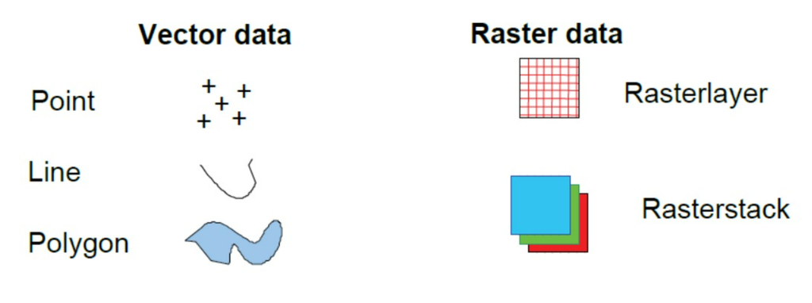

### Plot The Data

#### Data Vektor

Contoh: membuat objek spasial dari objek **data.frame** dari package `sp`

```r
library(sp)
data("meuse")
class(meuse)
```

```
## [1] "data.frame"
```

```r
head(meuse)
```

```
##        x      y cadmium copper lead zinc  elev       dist   om ffreq soil lime
## 1 181072 333611    11.7     85  299 1022 7.909 0.00135803 13.6     1    1    1
## 2 181025 333558     8.6     81  277 1141 6.983 0.01222430 14.0     1    1    1
## 3 181165 333537     6.5     68  199  640 7.800 0.10302900 13.0     1    1    1
## 4 181298 333484     2.6     81  116  257 7.655 0.19009400  8.0     1    2    0
## 5 181307 333330     2.8     48  117  269 7.480 0.27709000  8.7     1    2    0
## 6 181390 333260     3.0     61  137  281 7.791 0.36406700  7.8     1    2    0
##   landuse dist.m
## 1      Ah     50
## 2      Ah     30
## 3      Ah    150
## 4      Ga    270
## 5      Ah    380
## 6      Ga    470
```

```r
# converting to Spatial object:
coordinates(meuse) <- c("x","y")
class(meuse)
```

```
## [1] "SpatialPointsDataFrame"
## attr(,"package")
## [1] "sp"
```

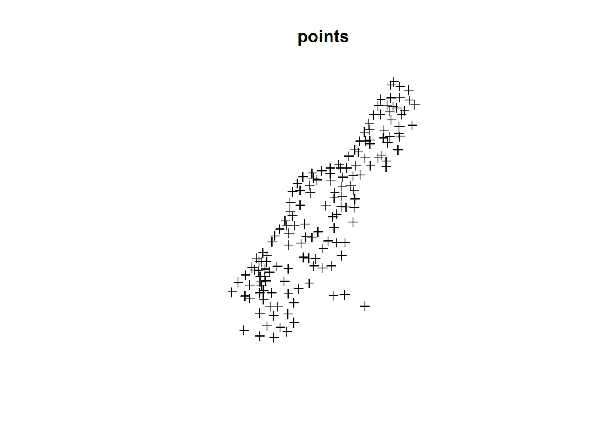

```r
plot(meuse, main = "points")
```

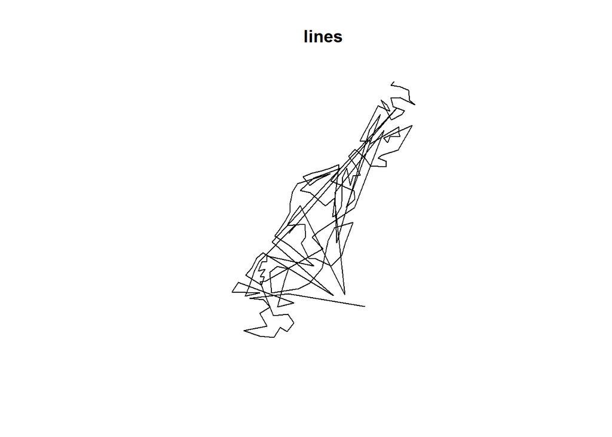

```r
cc <- coordinates(meuse)
m.sl <- SpatialLines(list(Lines(list(Line(cc)), "line1")))

plot(m.sl, main = "lines")
```

Objek **SpatialLines** dibuat dengan menggabungkan titik-titik secara berurutan

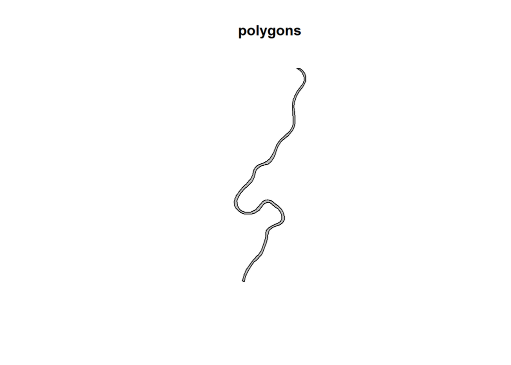

```r
data("meuse.riv")
meuse.lst <- list(Polygons(list(Polygon(meuse.riv)), "meuse.riv"))
meuse.pol <- SpatialPolygons(meuse.lst)

plot(meuse.pol, col = "grey", main ="polygons")
```

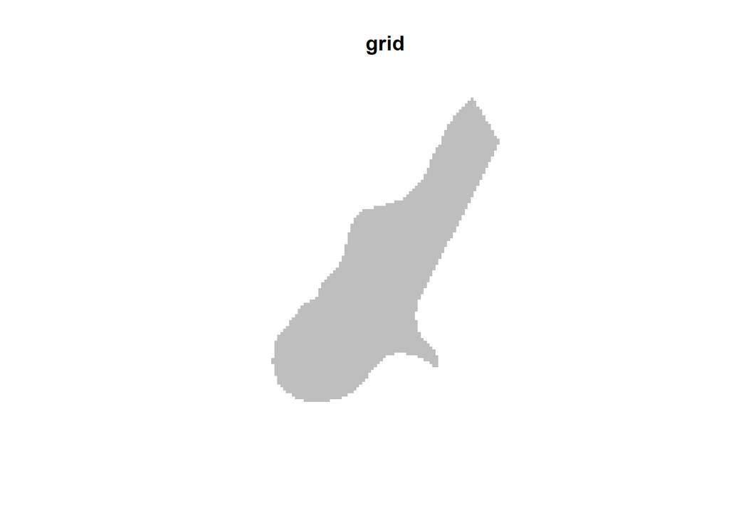

```r
data("meuse.grid")
coordinates(meuse.grid) <- c("x","y")
meuse.grid <- as(meuse.grid, "SpatialPixels")
image(meuse.grid, col = "grey", main = "grid")
```

Sebuah peta menjadi lebih mudah dibaca ketika kita menggabungkan beberapa elemen. Kita dapat menampilkan elemen dari yang dibuat di atas dengan menggunakan argumen add = TRUE.

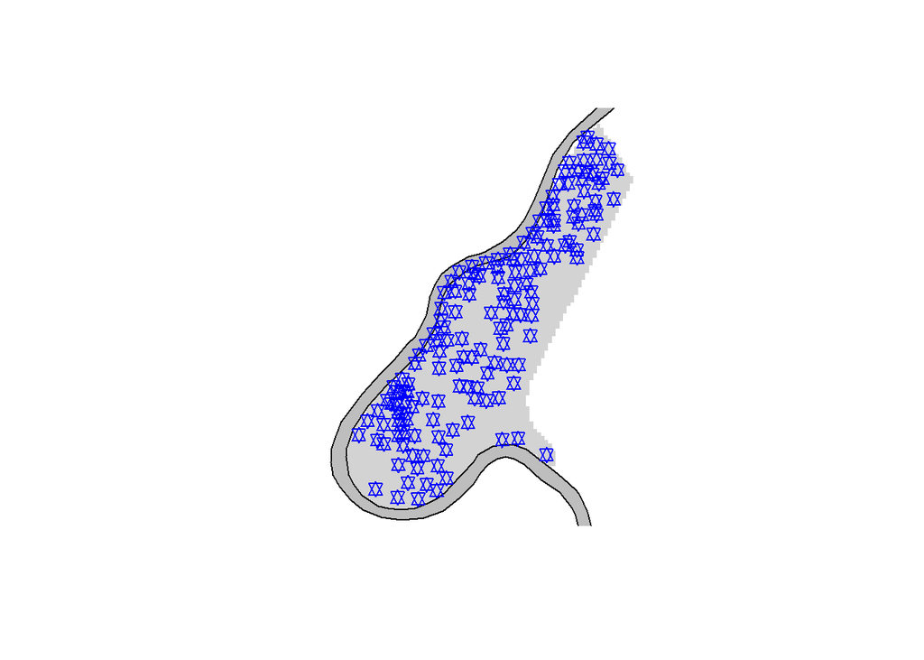

```r
image(meuse.grid, col = "lightgrey")
plot(meuse.pol, col = "grey", add = T)
plot(meuse, pch = 11 ,col = "blue", add = T)
```

#### Data Raster

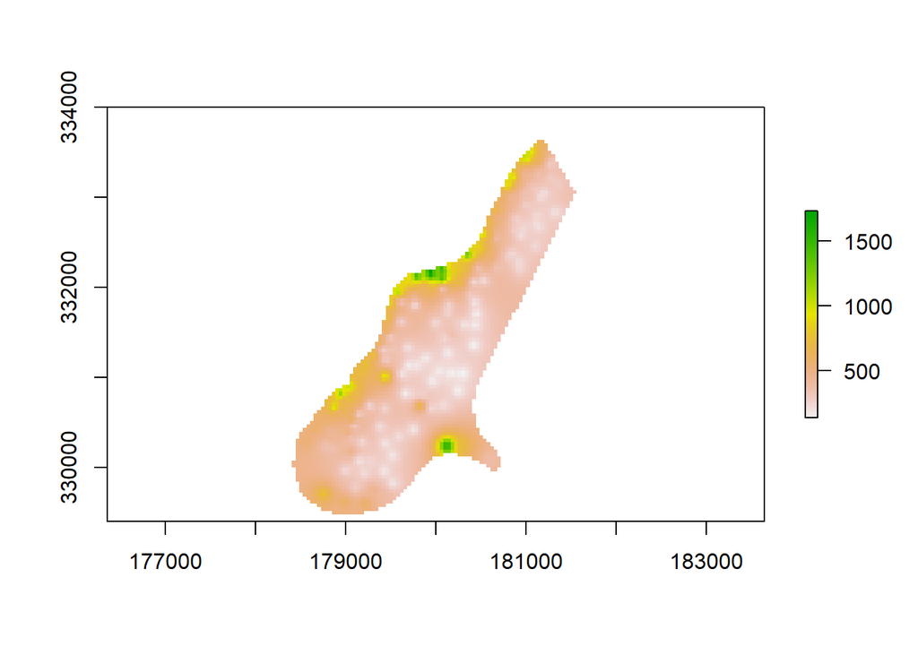

```r
f <- system.file("external/test.grd", package="raster")
library(raster)
r <- raster(f)
plot(r)
```

[figure not shown]

```r
slogo <- stack(system.file("external/rlogo.grd", package="raster"))
plot(slogo)
```

[figure not shown]

```r
plotRGB(slogo,axes = TRUE, stretch = "lin", main = "rlogo")
```

### Menggunakan Data Eksternal

Contoh: Data pertumbuhan penduduk

```r
datapop <- read.csv('http://bit.ly/Popgrowth2000', header=T, sep=',')
```

Dimensi data

```r
dim(datapop)
```

```
## [1] 293   5
```

Struktur data

```r
str(datapop)
```

```
## 'data.frame':    293 obs. of  5 variables:
##  $ City          : chr  "Abidjan" "Adana" "Addis Ababa" "Adelaide" ...
##  $ Country       : chr  "Cote d'Ivoire" "Turkey" "Ethiopia" "Australia" ...
##  $ Latitude      : num  5.31 37 9.02 -34.93 23.04 ...
##  $ Longitude     : num  -4.01 35.33 38.75 138.6 72.57 ...
##  $ PopGrowth_2000: int  1929000 1041000 2424000 1092000 2954000 1582000 3339000 2562000 1135000 1147000 ...
```

Tabel data

```r
head(datapop)
```

```
##          City       Country  Latitude Longitude PopGrowth_2000
## 1     Abidjan Cote d'Ivoire   5.30966  -4.01266        1929000
## 2       Adana        Turkey  37.00167  35.32889        1041000
## 3 Addis Ababa      Ethiopia   9.02497  38.74689        2424000
## 4    Adelaide     Australia -34.92866 138.59863        1092000
## 5   Ahmadabad         India  23.03957  72.56600        2954000
## 6      Aleppo         Syria  36.21670  37.16670        1582000
```

Plot the data points

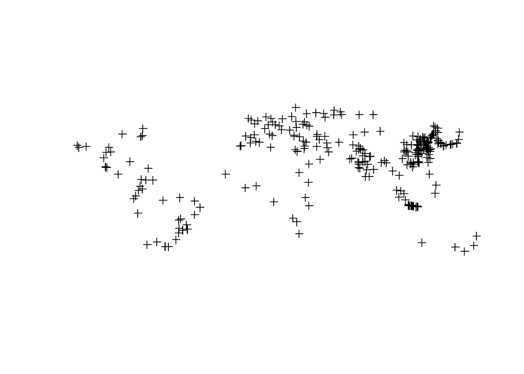

```r
coordinates(datapop) <- c("Longitude","Latitude")
plot(datapop)
```

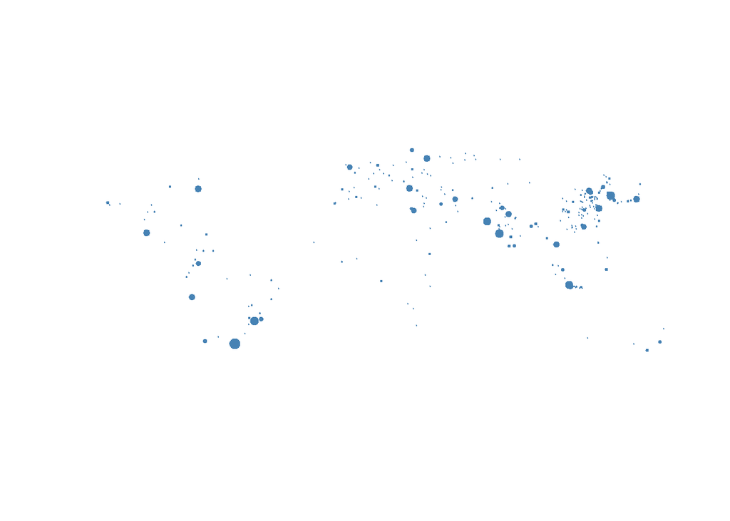

```r
size<-datapop$PopGrowth_2000/sum(datapop$PopGrowth_2000)
plot(datapop,pch=20, col="steelblue", cex=size*100)
```

Menambahkan peta dunia

```r
library(rworldmap)
data(package="rworldmap")
data(countriesCoarse,envir=environment(),package="rworldmap")
```

Peta dunia

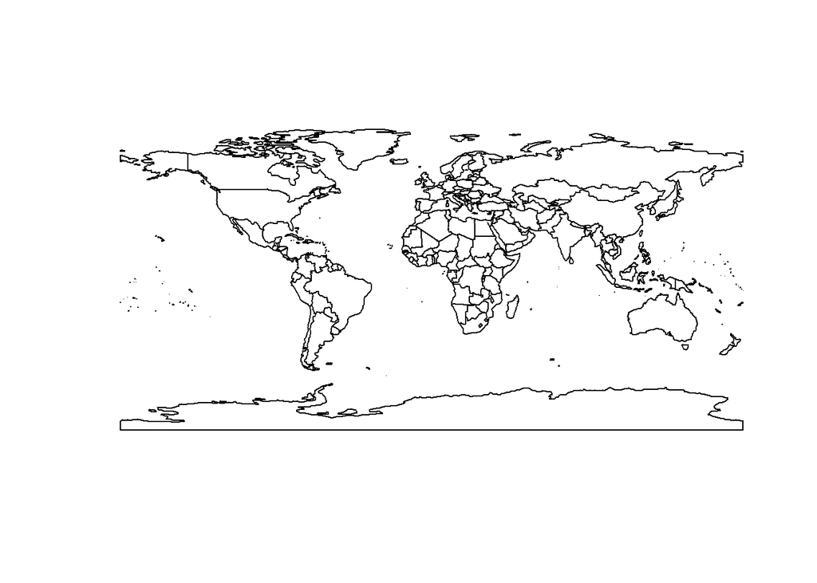

```r
plot(countriesCoarse)
```

Peta dunia + Data pertumbuhan penduduk

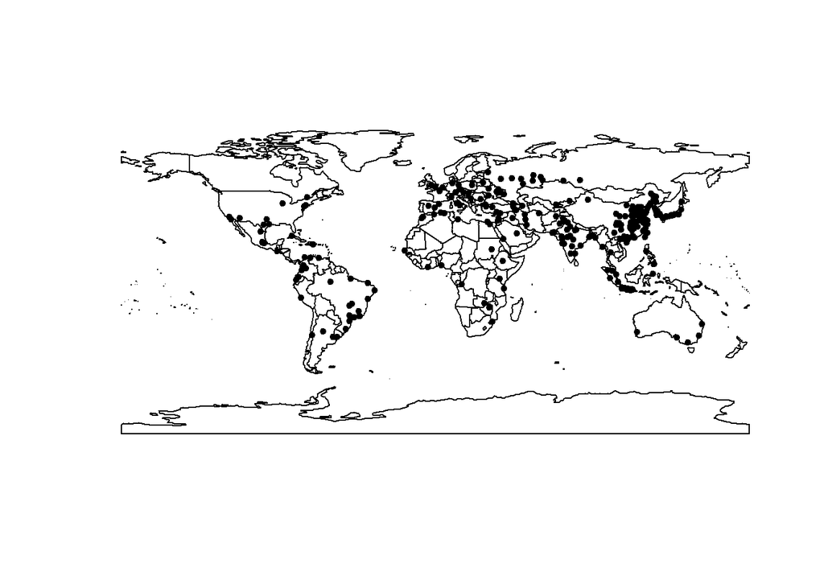

```r
plot(countriesCoarse)
plot(datapop,add=T, pch=20)
```

Rasterize

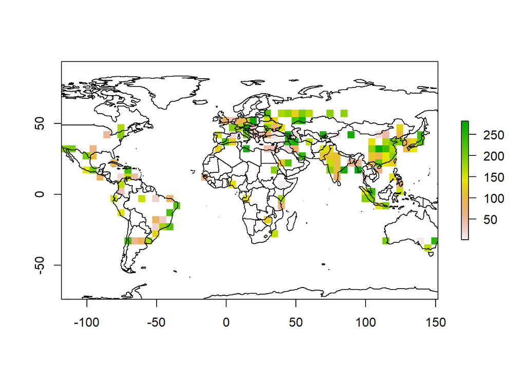

```r
library(raster)
r <- raster(datapop)
res(r)<-c(5,5)
nc <- rasterize(coordinates(datapop), r, fun=mean, background=NA)
plot(nc)
plot(countriesCoarse, add=TRUE)
```

Cara lain menampilkan peta

```r
library(datasets)
states<-as.data.frame(state.x77)
head(states)
```

```
##            Population Income Illiteracy Life Exp Murder HS Grad Frost   Area
## Alabama          3615   3624        2.1    69.05   15.1    41.3    20  50708
## Alaska            365   6315        1.5    69.31   11.3    66.7   152 566432
## Arizona          2212   4530        1.8    70.55    7.8    58.1    15 113417
## Arkansas         2110   3378        1.9    70.66   10.1    39.9    65  51945
## California      21198   5114        1.1    71.71   10.3    62.6    20 156361
## Colorado         2541   4884        0.7    72.06    6.8    63.9   166 103766
```

Pertama, kita akan coba menampilkan visualisasi data populasi di U.S menggunakan fungsi di dalam package `ggplot2`.

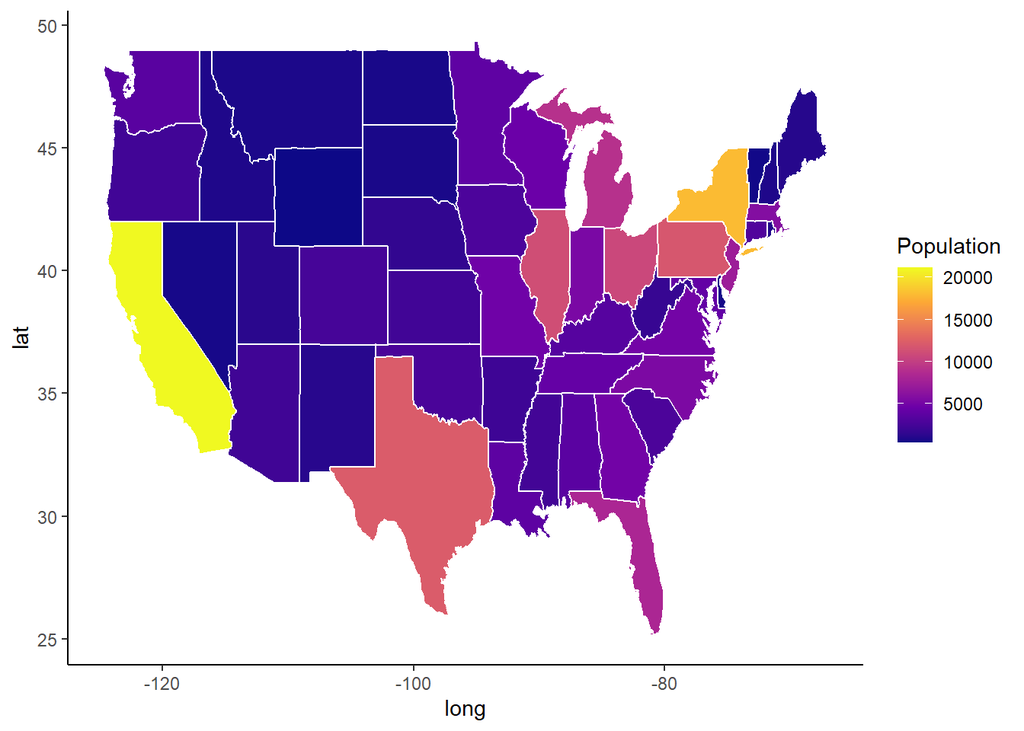

```r
library(ggplot2)
library(tidyverse)
states$region <- tolower(rownames(states))
states_map <- map_data("state")
fact_join <- left_join(states_map, states, by = "region")
ggplot(fact_join, aes(long, lat, group = group))+
  geom_polygon(aes(fill = Population), color = "white")+
  scale_fill_viridis_c(option = "C")+
  theme_classic()
```

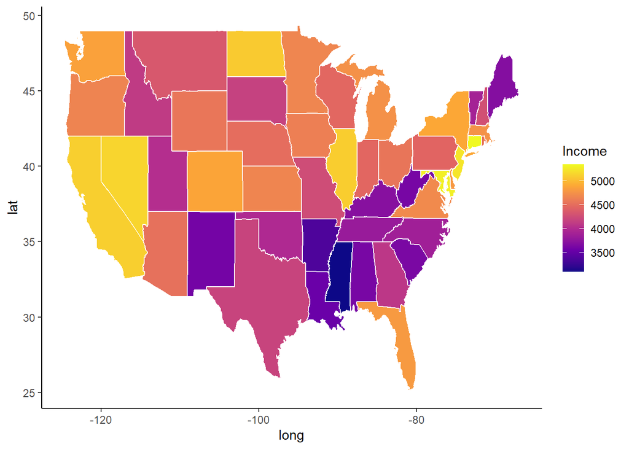

```r
ggplot(fact_join, aes(long, lat, group = group))+
  geom_polygon(aes(fill = Income), color = "white")+
  scale_fill_viridis_c(option = "C")+
  theme_classic()
```

Berikut apabila ingin menampilkan peubah lain, misalnya usia harapan hidup.

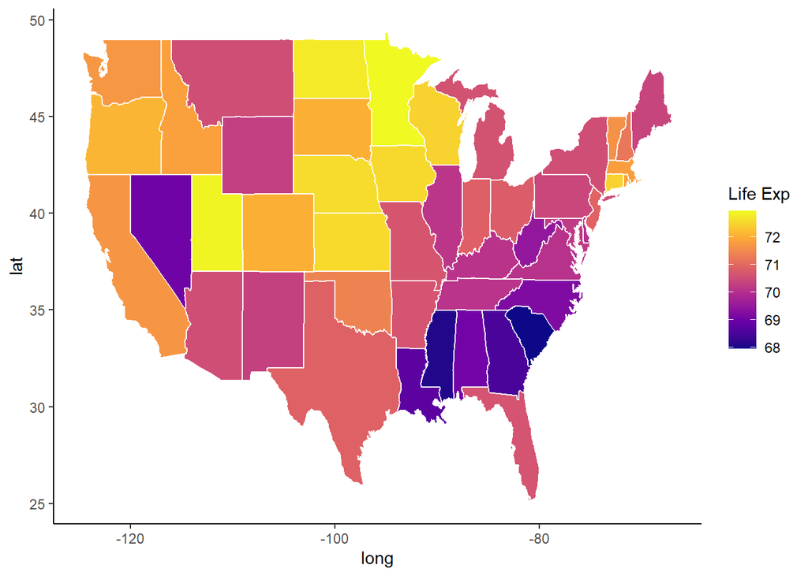

```r
fact_join$`Life Exp` <- as.numeric(fact_join$`Life Exp`)
ggplot(fact_join, aes(long, lat, group = group))+
geom_polygon(aes(fill = `Life Exp`), color = "white")+
scale_fill_viridis_c(option = "C")+
theme_classic()
```

## Ilustrasi: Data Cholera

Sebagai ilustrasi, akan digunakan data yang tersedia pada laman http://rtwilson.com/downloads/SnowGIS_SHP.zip. Pastikan Anda mengekstrak folder data tersebut pada direktori yang Anda inginkan. Selanjutnya, package `rgdal` akan digunakan untuk membaca data SnowGIS tersebut.

```r
library(rgdal)
```

Untuk melihat file apa saja yang ada di dalam folder shapefile tersebut, kita dapat menggunakan fungsi `list.files()`.

```r
dsn<-paste("C:/Users/Cintia/Documents/S2/ASISTEN/SnowGIS_SHP/SnowGIS_SHP")
list.files(dsn)
```

```
##  [1] "Cholera_Deaths.dbf"          "Cholera_Deaths.prj"
##  [3] "Cholera_Deaths.sbn"          "Cholera_Deaths.sbx"
##  [5] "Cholera_Deaths.shp"          "Cholera_Deaths.shx"
##  [7] "OSMap.tfw"                   "OSMap.tif"
##  [9] "OSMap_Grayscale.tfw"         "OSMap_Grayscale.tif"
## [11] "OSMap_Grayscale.tif.aux.xml" "OSMap_Grayscale.tif.ovr"
## [13] "Pumps.dbf"                   "Pumps.prj"
## [15] "Pumps.sbx"                   "Pumps.shp"
## [17] "Pumps.shx"                   "README.txt"
## [19] "SnowMap.tfw"                 "SnowMap.tif"
## [21] "SnowMap.tif.aux.xml"         "SnowMap.tif.ovr"
```

Terlihat pada output di atas bahwa folder tersebut memuat beberapa shapefile, diantaranya terdapat 6 file dengan nama `Cholera_Deaths` dan 5 file bernama `Pumps`. Kedua set data tersebut dikenal sebagai layer.

```r
ogrListLayers(dsn)
```

```
## [1] "Cholera_Deaths" "Pumps"
## attr(,"driver")
## [1] "ESRI Shapefile"
## attr(,"nlayers")
## [1] 2
```

Kita dapat menggunakan fungsi `ogrInfo()` untuk mengetahui informasi mengenai layer tersebut.

```r
ogrInfo(dsn, layer = "Cholera_Deaths")
```

```
## Driver: ESRI Shapefile; number of rows: 250
## Feature type: wkbPoint with 2 dimensions
## Extent: (529160.3 180857.9) - (529655.9 181306.2)
## CRS: +proj=tmerc +lat_0=49 +lon_0=-2 +k=0.9996012717 +x_0=400000 +y_0=-100000 +ellps=airy +units=m +no_defs
## LDID: 87
## Number of fields: 2
##    name type length typeName
## 1    Id    0      6  Integer
## 2 Count    0      4  Integer
```

```r
CholeraDeaths <- readOGR(dsn, layer = "Cholera_Deaths")
summary(CholeraDeaths)
```

```
## Object of class SpatialPointsDataFrame
## Coordinates:
##                min      max
## coords.x1 529160.3 529655.9
## coords.x2 180857.9 181306.2
## Is projected: TRUE
## proj4string :
## [+proj=tmerc +lat_0=49 +lon_0=-2 +k=0.9996012717 +x_0=400000
## +y_0=-100000 +ellps=airy +units=m +no_defs]
## Number of points: 250
## Data attributes:
##        Id        Count
##  Min.   :0   Min.   : 1.000
##  1st Qu.:0   1st Qu.: 1.000
##  Median :0   Median : 1.000
##  Mean   :0   Mean   : 1.956
##  3rd Qu.:0   3rd Qu.: 2.000
##  Max.   :0   Max.   :15.000
```

Selanjutnya kita dapat memeriksa `class` dari data `CholeraDeaths` tersebut.

```r
class(CholeraDeaths)
```

```
## [1] "SpatialPointsDataFrame"
## attr(,"package")
## [1] "sp"
```

Data tersebut merupakan **SpatialPointsDataFrame**, maka untuk mengakses data slot perlu digunakan notasi `@`.

```r
str(CholeraDeaths@data)
```

```
## 'data.frame':    250 obs. of  2 variables:
##  $ Id   : int  0 0 0 0 0 0 0 0 0 0 ...
##  $ Count: int  3 2 1 1 4 2 2 2 3 2 ...
```

Fungsi `plot()` dapat digunakan untuk membuat grafik paling sederhana dari data `CholeraDeaths`.

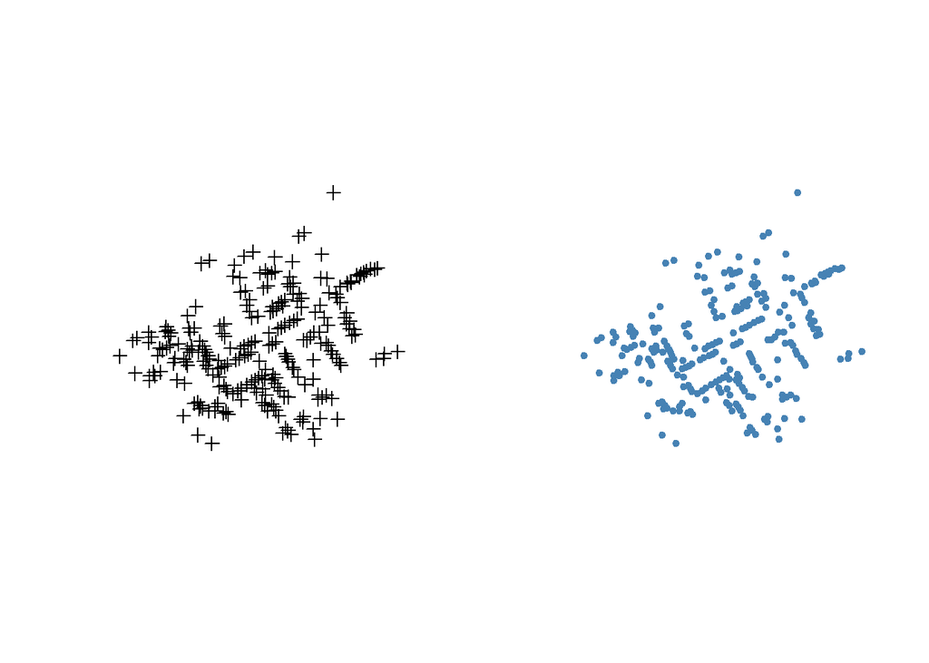

```r
par(mfrow=c(1,2))
plot(CholeraDeaths)
plot(CholeraDeaths, pch=20, col="steelblue")
```

Perhatikan bahwa plot di atas hanya menunjukkan sebaran titik spasial, tanpa memberikan informasi yang jelas tentang lokasi data tersebut. Jika kita memiliki peta dalam bentuk data polygon, kita dapat mengimpor data tersebut dengan cara yang sama (seandainya datanya berupa shapefile), kemudian kita plot peta, baru kemudian plot data titik seperti di atas.

Alternatif lainnya jika kita tidak ingin menggunakan peta polygon dari shapefile, kita dapat menggunakan beberapa package yang tersedia di R software, seperti `ggmap`, `OpenStreetMap`, `leaflet`, atau yang lain. Namun perhatikan bahwa untuk bisa menggunakan package `OpenStreetMap`, Anda harus memastikan bahwa jika Anda menggunakan R 64-bit maka Java yang terinstall di PC Anda juga harus sesuai, yaitu 64-bit.

Berikut ini akan ditunjukkan salah satu cara menampilkan peta dengan memanfaatkan package `leaflet`.

```r
library(leaflet)
map <- leaflet() %>% setView(lng =  -0.13659, lat =51.51328 , zoom = 12)
map %>% addTiles()
```

[interactive chart not shown]

Sebelum kedua peta dan data titik digabungkan. Pastikan terlebih dahulu apakah koordinat yang digunakan menggunakan skala yang sama.

```r
head(coordinates(CholeraDeaths))
```

```
##      coords.x1 coords.x2
## [1,]  529308.7  181031.4
## [2,]  529312.2  181025.2
## [3,]  529314.4  181020.3
## [4,]  529317.4  181014.3
## [5,]  529320.7  181007.9
## [6,]  529336.7  181006.0
```

Seperti terlihat di atas, koordinat pada data `CholeraDeaths` diukur pada skala yang berbeda dengan peta yang diambil dari package `leaflet`. Terdapat beberapa macam coordinate reference system (CRS), beberapa diantaranya yang cukup populer adalah suatu set EPSG (*European Petroleum Survey Group*) berikut:

- **EPSG:4326** juga dikenal sebagai WGS84, ukuran standard yang digunakan pada sistem GPS dan Google Earth.
- **EPSG:3857** digunakan pada Google Maps, Open Street Maps, dsb.
- **EPSG:27700** juga dikenal sebagai OSGB 1936, atau British National Grid: United Kingdom Ordnance Survey.

Berikut ini dilakukan transformasi menjasi WGS84.

```r
cholera_latlong <- CholeraDeaths %>%
  spTransform(CRS("+init=epsg:4326"))
```

Berikut ini, untuk menggabungkan peta dan titik.

```r
leaflet(data = CholeraDeaths) %>%
  addTiles() %>%
  addMarkers(cholera_latlong@coords[,1], cholera_latlong@coords[,2])
```

[interactive chart not shown]

Dapat dilihat di atas, bahwa setelah koordinatnya disamakan, kita dapat menampilkan data `CholeraDeaths` pada peta yang diperoleh dari `Open Street Map` melalui package `leaflet.`

## Latihan Mandiri : Peta Pulau Jawa

1. Load package `rgdal` untuk mengimpor data polygon (shape file).
2. Mengimpor data dari direktori.

   Data tersedia di http://bit.ly/ShapeFile_Jawa
3. Menampilkan peta Pulau Jawa
4. Menampilkan nama kabupaten/kota
5. Memberi warna yang berbeda untuk setiap provinsi